# Laboratorio44-MD

Leislie R. Manjarrez O.

2023-03-08

Hecho con gusto por Leislie R. Manjarrez O.

Laboratorio 44- Mapa de calor con BD en R

Preguntamos en R respecto a la BD que utilizaremos

```r
?mtcars
```

```
## starting httpd help server ... done
```

Caracteristicas muy variables que no estan normalizadas ni son las mismas medidas

Llamamos a la BD para observar las caracteristicas en la consola

```r
mtcars
```

```
##                      mpg cyl  disp  hp drat    wt  qsec vs am gear carb
## Mazda RX4           21.0   6 160.0 110 3.90 2.620 16.46  0  1    4    4
## Mazda RX4 Wag       21.0   6 160.0 110 3.90 2.875 17.02  0  1    4    4
## Datsun 710          22.8   4 108.0  93 3.85 2.320 18.61  1  1    4    1
## Hornet 4 Drive      21.4   6 258.0 110 3.08 3.215 19.44  1  0    3    1
## Hornet Sportabout   18.7   8 360.0 175 3.15 3.440 17.02  0  0    3    2
## Valiant             18.1   6 225.0 105 2.76 3.460 20.22  1  0    3    1
## Duster 360          14.3   8 360.0 245 3.21 3.570 15.84  0  0    3    4
## Merc 240D           24.4   4 146.7  62 3.69 3.190 20.00  1  0    4    2
## Merc 230            22.8   4 140.8  95 3.92 3.150 22.90  1  0    4    2
## Merc 280            19.2   6 167.6 123 3.92 3.440 18.30  1  0    4    4
## Merc 280C           17.8   6 167.6 123 3.92 3.440 18.90  1  0    4    4
## Merc 450SE          16.4   8 275.8 180 3.07 4.070 17.40  0  0    3    3
## Merc 450SL          17.3   8 275.8 180 3.07 3.730 17.60  0  0    3    3
## Merc 450SLC         15.2   8 275.8 180 3.07 3.780 18.00  0  0    3    3
## Cadillac Fleetwood  10.4   8 472.0 205 2.93 5.250 17.98  0  0    3    4
## Lincoln Continental 10.4   8 460.0 215 3.00 5.424 17.82  0  0    3    4
## Chrysler Imperial   14.7   8 440.0 230 3.23 5.345 17.42  0  0    3    4
## Fiat 128            32.4   4  78.7  66 4.08 2.200 19.47  1  1    4    1
## Honda Civic         30.4   4  75.7  52 4.93 1.615 18.52  1  1    4    2
## Toyota Corolla      33.9   4  71.1  65 4.22 1.835 19.90  1  1    4    1
## Toyota Corona       21.5   4 120.1  97 3.70 2.465 20.01  1  0    3    1
## Dodge Challenger    15.5   8 318.0 150 2.76 3.520 16.87  0  0    3    2
## AMC Javelin         15.2   8 304.0 150 3.15 3.435 17.30  0  0    3    2
## Camaro Z28          13.3   8 350.0 245 3.73 3.840 15.41  0  0    3    4
## Pontiac Firebird    19.2   8 400.0 175 3.08 3.845 17.05  0  0    3    2
## Fiat X1-9           27.3   4  79.0  66 4.08 1.935 18.90  1  1    4    1
## Porsche 914-2       26.0   4 120.3  91 4.43 2.140 16.70  0  1    5    2
## Lotus Europa        30.4   4  95.1 113 3.77 1.513 16.90  1  1    5    2
## Ford Pantera L      15.8   8 351.0 264 4.22 3.170 14.50  0  1    5    4
## Ferrari Dino        19.7   6 145.0 175 3.62 2.770 15.50  0  1    5    6
## Maserati Bora       15.0   8 301.0 335 3.54 3.570 14.60  0  1    5    8
## Volvo 142E          21.4   4 121.0 109 4.11 2.780 18.60  1  1    4    2
```

Identificacion del tipo de dato que es mtcars

```r
class(mtcars)
```

```
## [1] "data.frame"
```

Convertimos el dataframe a una matriz

```r
mtcars_matriz <- data.matrix(mtcars)
```

Ver los datos en matriz

```r
head(mtcars_matriz)
```

```
##                    mpg cyl disp  hp drat    wt  qsec vs am gear carb
## Mazda RX4         21.0   6  160 110 3.90 2.620 16.46  0  1    4    4
## Mazda RX4 Wag     21.0   6  160 110 3.90 2.875 17.02  0  1    4    4
## Datsun 710        22.8   4  108  93 3.85 2.320 18.61  1  1    4    1
## Hornet 4 Drive    21.4   6  258 110 3.08 3.215 19.44  1  0    3    1
## Hornet Sportabout 18.7   8  360 175 3.15 3.440 17.02  0  0    3    2
## Valiant           18.1   6  225 105 2.76 3.460 20.22  1  0    3    1
```

Verificar que los datos estan en matriz

```r
class(mtcars_matriz)
```

```
## [1] "matrix" "array"
```

Crear primer grafico de calor

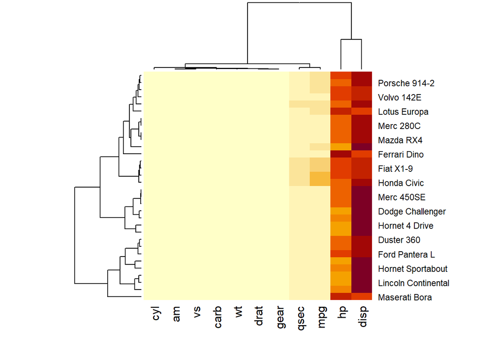

```r
heatmap(mtcars_matriz)
```

El resultado es que se grafican los renglones y no las columnas por lo que el grafo no nos dice mucho. Para conocer mas sobre heatmap puede preguntarse

```r
?heatmap
```

Hacer un nuevo mapa de calor graficando las columnas y no renglones

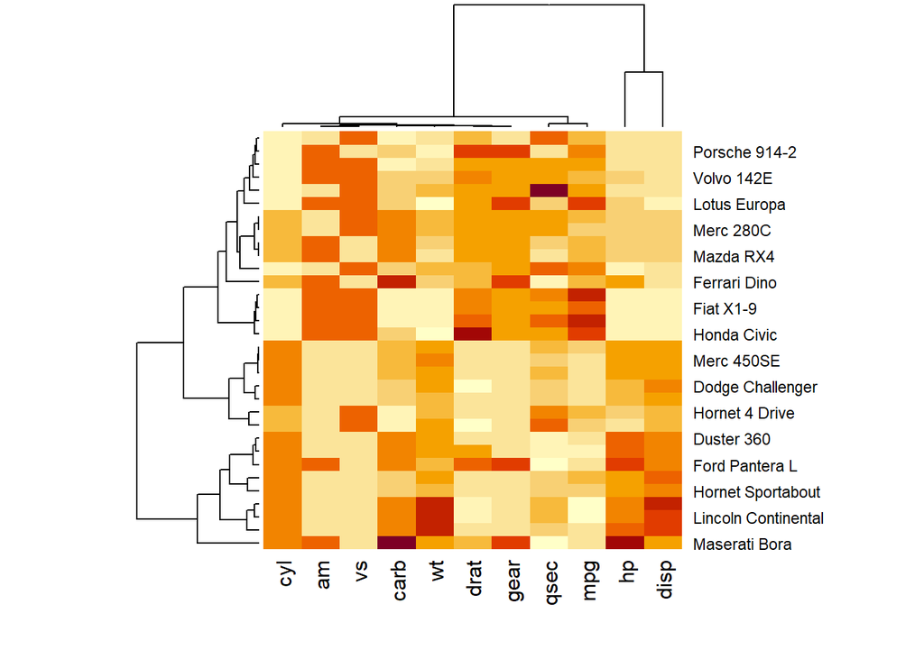

```r
heatmap(mtcars_matriz, scale = "colum")
```

Hacer una paleta personalizada de colores

```r
colores_blue <- colorRampPalette(c("lightblue", "cornflowerblue", "navyblue"))(256)
```

Volvemos a graficar considerando la paleta de colores creada

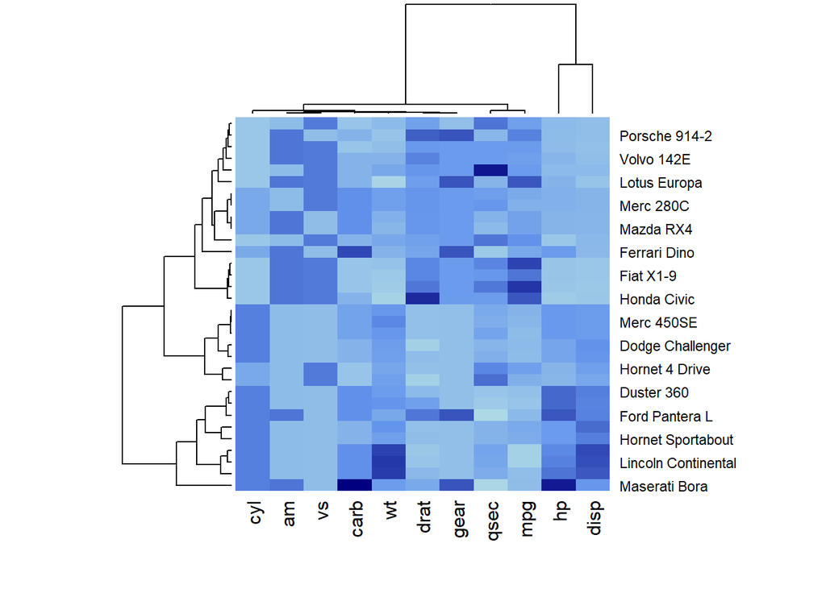

```r
heatmap(mtcars_matriz,
        scale = "colum",
        col = colores_blue)
```

Graficar eliminando el dendrograma horizontal por no contar con datos normalizados

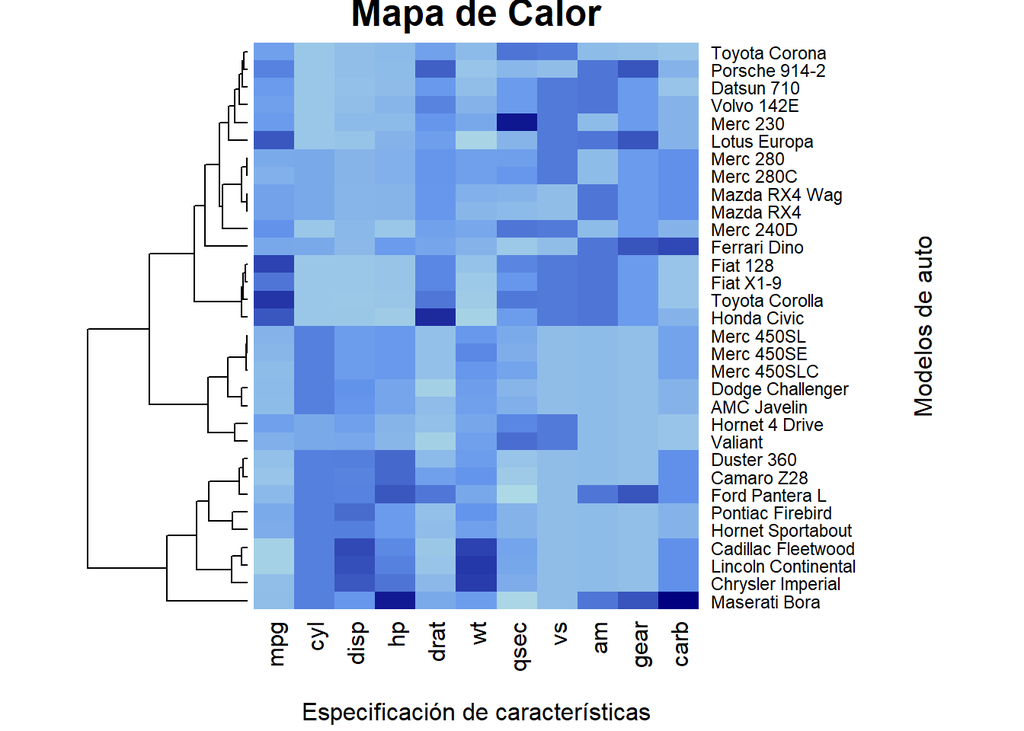

```r
heatmap(mtcars_matriz,
        scale = "colum",
        col = colores_blue,
        Colv = NA,
        margins = c(5,10),
        xlab = "Especificación de características",
        ylab = "Modelos de auto",
        main = "Mapa de Calor")
```

El orden de los autos es conforme al dendrograma y no se modifica el orden de las columnas como puede verse con el siguiente comando. Los coches se ordenaron de acuerdo al clusteo presentado en el dendrograma

```r
colnames(mtcars_matriz)
```

```
##  [1] "mpg"  "cyl"  "disp" "hp"   "drat" "wt"   "qsec" "vs"   "am"   "gear"
## [11] "carb"
```

Para cambiar el color del mapa de color instalamos primero la paqueteria install.packages(“viridis”)

Llamamos a la libreria de la paqueteria

```r
library(viridis)
```

Utilizamos la paleta viridis

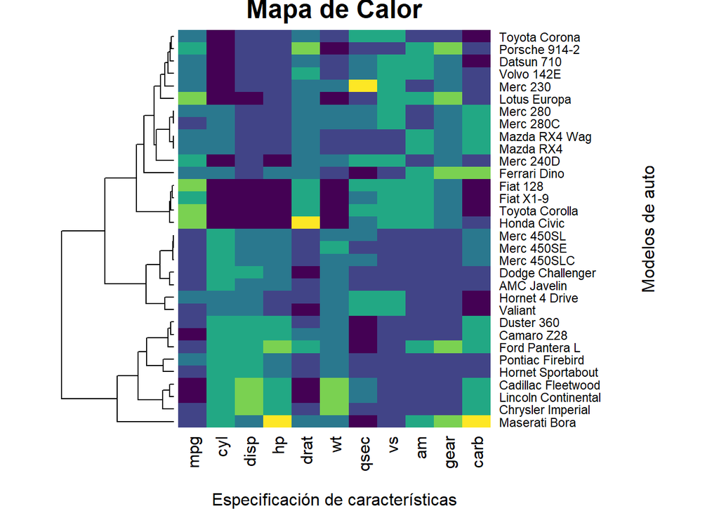

```r
heatmap(mtcars_matriz,
        scale = "colum",
        col = viridis_pal(option = "viridis") (6),
        Colv = NA,
        margins = c(5,10),
        xlab = "Especificación de características",
        ylab = "Modelos de auto",
        main = "Mapa de Calor")
```

Utilizamos la paleta magma

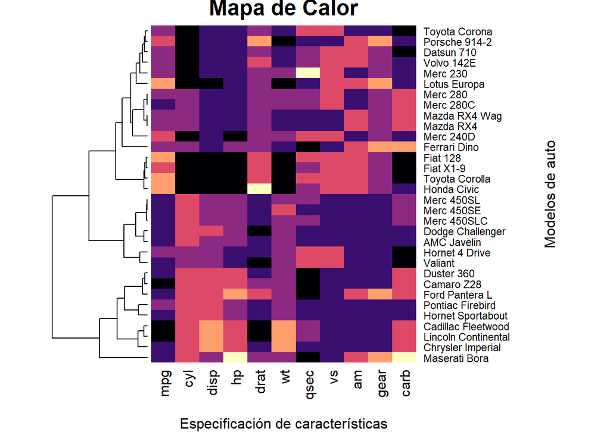

```r
heatmap(mtcars_matriz,
        scale = "colum",
        col = viridis_pal(option = "magma") (6),
        Colv = NA,
        margins = c(5,10),
        xlab = "Especificación de características",
        ylab = "Modelos de auto",
        main = "Mapa de Calor")
```

Utilizamos la paleta rainbow

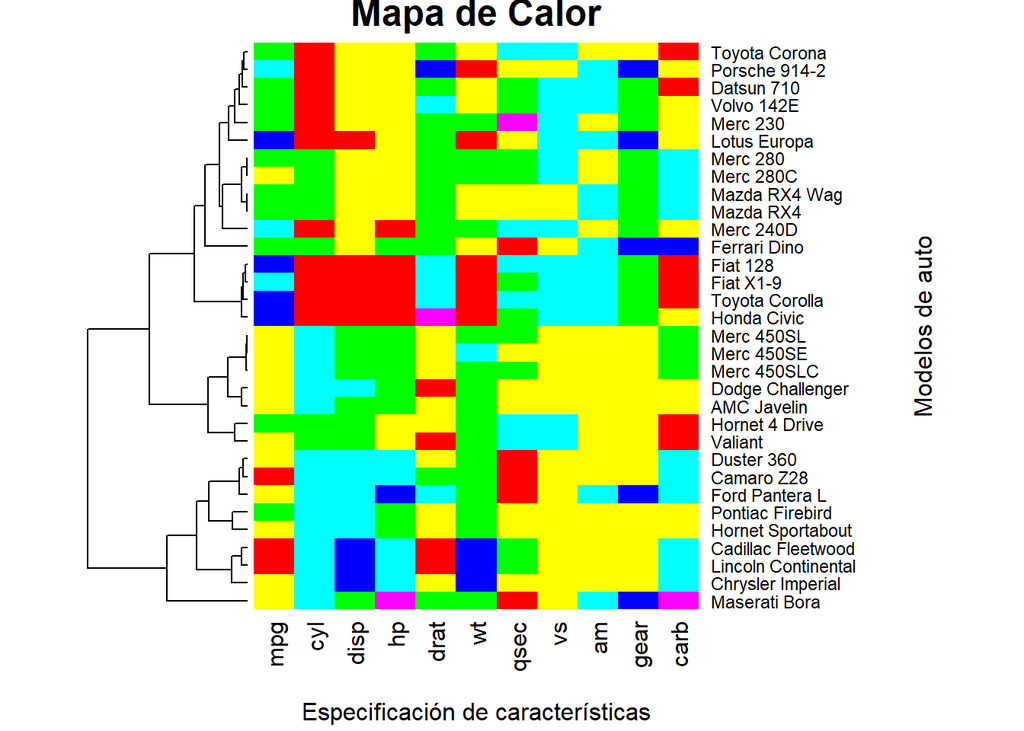

```r
heatmap(mtcars_matriz,
        scale = "colum",
        col = rainbow (6),
        Colv = NA,
        margins = c(5,10),
        xlab = "Especificación de características",
        ylab = "Modelos de auto",
        main = "Mapa de Calor")
```

Para conocer cuales son los valores mas altos y bajos corremos el siguiente comando

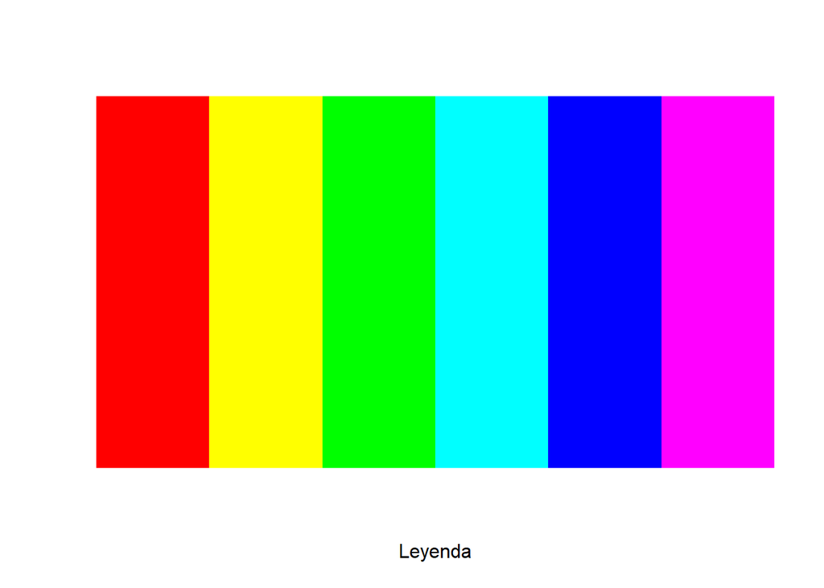

```r
image(1:6,1,as.matrix(1:6), col = rainbow (6), xlab="Leyenda", ylab="", xaxt="n", yaxt="n", bty="n")
```

En este caso el color rojo es el mas bajo y el morado el mas alto.